# COVID -19 INDIA

COVID -19 INDIA Pratyush Singh 02/10/2020

## COVID-19 INDIA

This is a detailed data analysis of Covid-19 Data in india , Aiming to extract insights on variables effecting State-Wise performace in combating the pandemic and reaching factual conclusions supported by data .

The Data Used was obtained from the following links :  
Covid-19 India Dataset - https://www.kaggle.com/sudalairajkumar/covid19-in-india?select=covid_19_india.csv  
India shp file - https://codeload.github.com/arka1985/MAP_INDIA_R/zip/master  
Indian Rural Population - https://hetv.org/india/india-rural-urban-distribution-of-population-2011.xls  
Indian Population Dataset https://storage.googleapis.com/kaggle-data-sets/557629%2F1489204%2Fbundle%2Far

# State-Wise Confirmed Cases per Million

| id | confirmed_per_million |
| --- | --- |
| Andaman &amp; Nicobar Island | 9346.23641222236 |
| Andhra Pradesh | 11599.6894776203 |
| Arunanchal Pradesh | 4551.47583302198 |
| Assam | 4619.87947282242 |
| Bihar | 1540.50762918521 |
| Chandigarh | 7811.83381496044 |
| Chhattisgarh | 2635.60298103777 |
| NCT of Delhi | 13195.9601239961 |
| Goa | 17070.4366337686 |
| Gujarat | 1899.97659154186 |

[output cut: 26 more lines]

# State-Wise COVID-19 Tests Performed Per Million

| id | samples_per_million |
| --- | --- |
| Andhra Pradesh | 94022.3352703767 |
| Arunanchal Pradesh | 150437.18883855 |
| Assam | 88126.4617579884 |
| Bihar | 47903.6815678914 |
| Chandigarh | 49000.900090009 |
| Chhattisgarh | 31553.6798736107 |
| NCT of Delhi | 130112.203753873 |
| Goa | 154887.233510108 |
| Gujarat | 55597.8677058778 |
| Haryana | 59743.102784368 |

[output cut: 26 more lines]

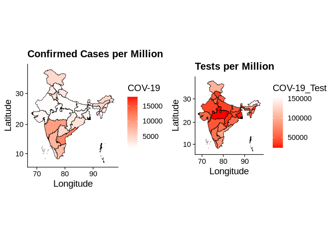

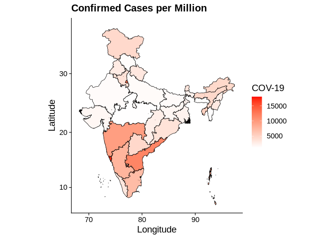

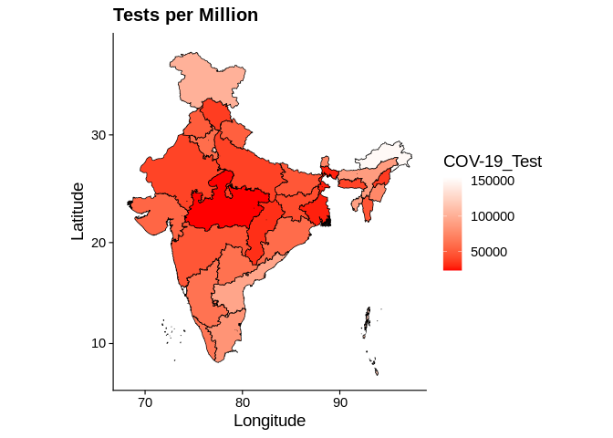

# Population Density of Each State

| State / Union Territory | Density |
| --- | --- |
| Uttar Pradesh | 828/km2 (2,140/sq mi) |
| Maharashtra | 365/km2 (950/sq mi) |
| Bihar | 1,102/km2 (2,850/sq mi) |
| West Bengal | 1,029/km2 (2,670/sq mi) |
| Madhya Pradesh | 236/km2 (610/sq mi) |
| Tamil Nadu | 555/km2 (1,440/sq mi) |
| Rajasthan | 201/km2 (520/sq mi) |
| Karnataka | 319/km2 (830/sq mi) |
| Gujarat | 308/km2 (800/sq mi) |
| Andhra Pradesh | 303/km2 (780/sq mi) |

[output cut: 26 more lines]

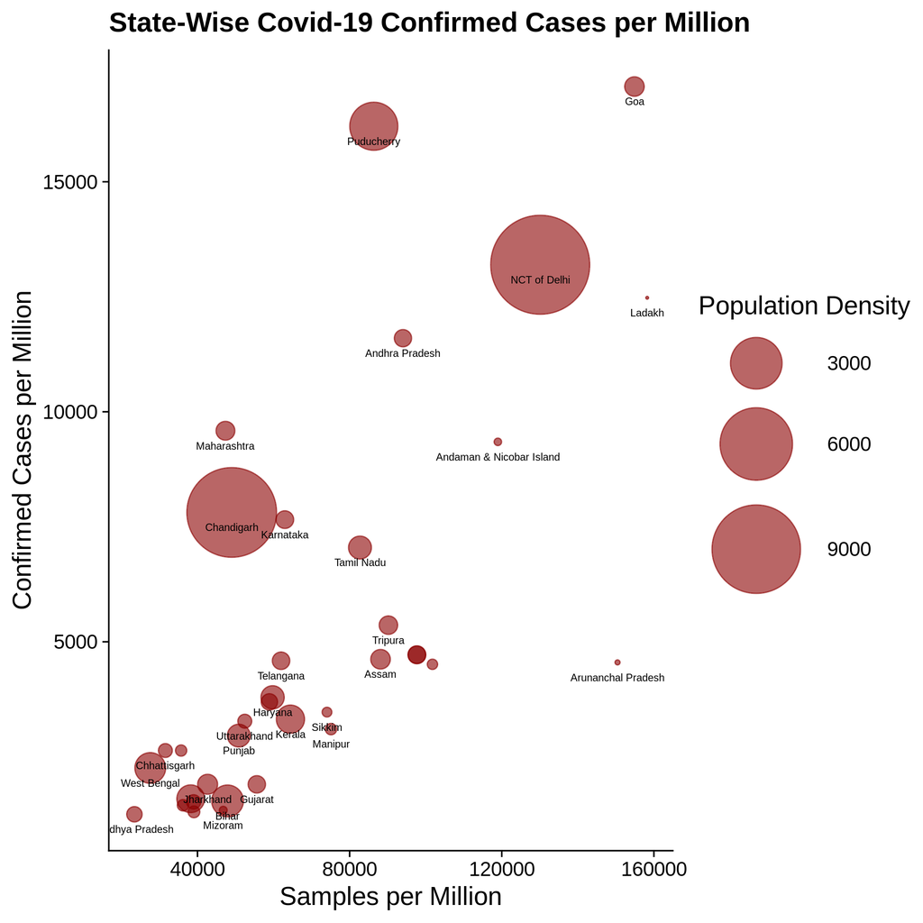

POPULATION DENSITY

**Population Density** **does not seem to have a major pattern in the performance of states against the pandemic** **as seen states having comparatively lower density are mostly at the bottom left corner of the plot with some towards the top right , Similarly Denser states are also spread allover the graph**

# Rural Density Of Each State

| id | Rural% | Urban% | rural_prop |
| --- | --- | --- | --- |
| Jammu &amp; Kashmir | 72.7936398700574 | 27.2063601299426 | 2.67561112630949 |
| Himachal Pradesh | 89.9554715088976 | 10.0445284911024 | 8.95566890855869 |
| Punjab | 62.5059647918102 | 37.4940352081898 | 1.6670908971184 |
| Chandigarh | 2.7500128000182 | 97.2499871999818 | 0.0282777703030764 |
| Uttarakhand | 69.4450452081854 | 30.5549547918146 | 2.27279162025758 |
| Haryana | 65.2050652147563 | 34.7949347852437 | 1.87398153257667 |
| Nct Of Delhi | 2.50291361638513 | 97.4970863836149 | 0.0256716760389854 |
| Rajasthan | 75.1085338117718 | 24.8914661882282 | 3.01744112796749 |
| Uttar Pradesh | 77.7181451563263 | 22.2818548436737 | 3.4879567119338 |
| Bihar | 88.7003034363484 | 11.2996965636516 | 7.84979516367511 |

[output cut: 25 more lines]

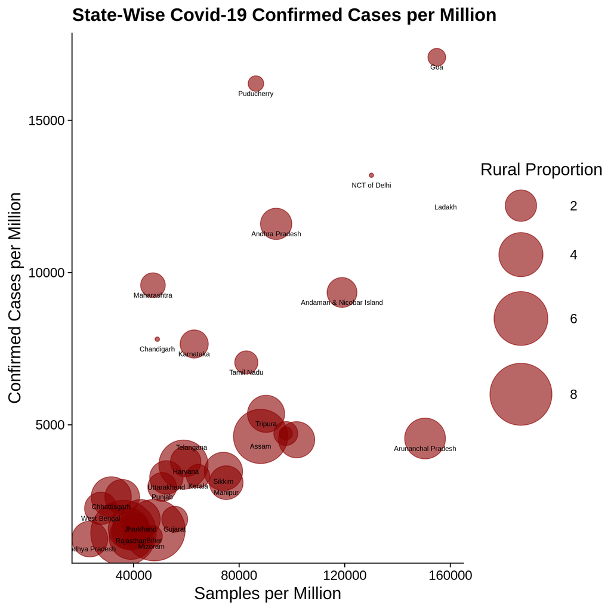

RURAL DENSITY

**The plot reveals a clear pattern showing the significant effect of rural population on each state’s performance against the pandemic , with states with higher rural proportion residing mostly towards the bottom left whereas urban states are towards the top right**  
**Though the plot also suggests that there are outliers such as Arunanchal Pradesh , Andaman & Nicobar Islands and Andhra Pradesh which are performing relatively better despite higher rural population**  
**Similarly States such as Chandigarh , Kerala and Maharashtra are relatively in worse position despite being mostly urban**

[figure not shown]

## CONCLUSION

Most states in India have improved their overall testing per million

**Yet** some states have performed significantly better than others while some have done worse ,

This goes to show that although their are multiple varibales which effect the performance of a region against a pandemic their is a significant scope for **good management and bad management** by respective state governance and authorities.